# From a shareholder to stakeholder orientation: Evidence from the analyses of CEO dismissal in large U.S. firms

Converted from PDF `Shin-StakeholderOrientationCEODismissal-2022-SMJ.pdf` · 25 pages · anchors: page `#pN`, block `#pN-bK`

Page 1

R E S E A R C H A R T I C L E

## From a shareholder to stakeholder orientation: Evidence from the analyses of CEO dismissal in large U.S. firms

Shoonchul Shin<sup>1</sup> | Juyoung Lee<sup>2</sup> | Pratima (Tima) Bansal<sup>3</sup>

1Business School, Aalborg University, Aalborg, Denmark

2Faculty of Business, The Hong Kong Polytechnic University, Kowloon, Hong Kong

3Ivey Business School, Western University, London, Ontario, Canada

Correspondence Shoonchul Shin, Aalborg University, Business School, Fibigerstræde 11, Office 64, 9220 Aalborg, Denmark. Email: shoonchuls@business.aau.dk

Funding information Social Sciences and Humanities Research Council of Canada, Grant/Award Number: 435-2013-1409

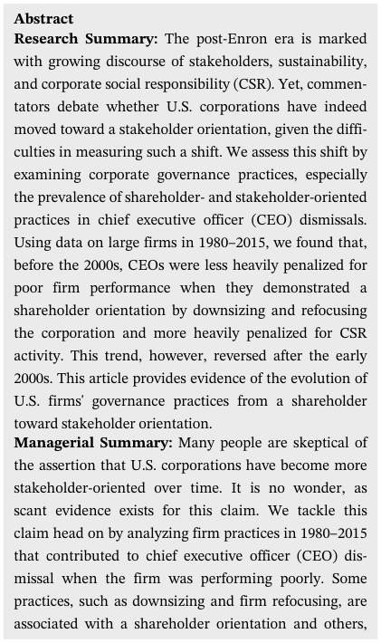

NOTE: figure/graphic rendered as an image from the PDF; its content is not machine-readable text. Caption (if any) follows as the next block.

**text found inside the figure**

Abstract Research Summary: The post-Enron era is marked

with growing discourse of stakeholders, sustainability, and corporate social responsibility (CSR). Yet, commen-

tators debate whether U.S. corporations have indeed moved toward a stakeholder orientation, given the diffi-

culties in measuring such a shift. We assess this shift by examining corporate governance practices, especially

the prevalence of shareholder- and stakeholder-oriented

practices in chief executive officer (CEO) dismissals. Using data on large firms in 1980–2015, we found that,

before the 2000s, CEOs were less heavily penalized for poor firm performance when they demonstrated a

shareholder orientation by downsizing and refocusing

the corporation and more heavily penalized for CSR activity. This trend, however, reversed after the early

2000s. This article provides evidence of the evolution of U.S. firms' governance practices from a shareholder

toward stakeholder orientation. Managerial Summary: Many people are skeptical of

the assertion that U.S. corporations have become more stakeholder-oriented over time. It is no wonder, as

scant evidence exists for this claim. We tackle this

claim head on by analyzing firm practices in 1980–2015 that contributed to chief executive officer (CEO) dis-

missal when the firm was performing poorly. Some practices, such as downsizing and firm refocusing, are

associated with a shareholder orientation and others,

Received: 8 February 2021 Revised: 15 November 2021 Accepted: 19 November 2021 Published on: 29 December 2021

DOI: 10.1002/smj.3369

Strat Mgmt J. 2022;43:1233–1257. wileyonlinelibrary.com/journal/smj © 2021 John Wiley & Sons Ltd. 1233

Page 2

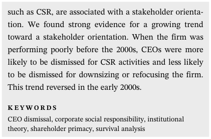

NOTE: figure/graphic rendered as an image from the PDF; its content is not machine-readable text. Caption (if any) follows as the next block.

**text found inside the figure**

such as CSR, are associated with a stakeholder orienta-

tion. We found strong evidence for a growing trend toward a stakeholder orientation. When the firm was

performing poorly before the 2000s, CEOs were more likely to be dismissed for CSR activities and less likely

to be dismissed for downsizing or refocusing the firm.

This trend reversed in the early 2000s.

K E Y W O R D S

CEO dismissal, corporate social responsibility, institutional theory, shareholder primacy, survival analysis

#### 1 | INTRODUCTION

“In the Business Roundtable's view, the paramount duty of management and of boards of directors is to the corporation's stockholders; the interests of other stakeholders are relevant as a derivative of the duty to stockholders.” (Business Roundtable, 1997) “While each of our individual companies serves its own corporate purpose, we share a fundamental commitment to all of our stakeholders.” (Business Roundtable, 2019)

In September 1997, the Business Roundtable, a group of nearly 200 chief executive officers (CEOs) from large U.S. firms, published a statement declaring that the primary purpose of a corporation is to maximize shareholder value (see above 1997 quote). This statement represents a distinct ideology of American business, known as an agency logic or a shareholder primacy model of corporate governance. Just over two decades later, however, the group changed position to release a new statement defining corporate purpose in terms of the interests of various stakeholder groups, such as employees, customers, suppliers, and communities (see above 2019 quote). This appears to reflect an important shift in the purpose and practice of U.S. corporations.

Under the agency logic, the social responsibility of business is to generate economic returns for shareholders and governments are mandated to set the rules of the game for business in order to protect societal concerns (Friedman, 1970; Jensen & Meckling, 1976). The shareholder value ideology rapidly grew in prominence during the takeover wave of the 1980s, when hostile tender offers, leveraged buyouts, and corporate restructuring were prevalent (Davis, Diekmann, & Tinsley, 1994; Fligstein, 2001; Hoskisson & Hitt, 1994; Useem, 1996). In the late 1980s and 1990s, shareholder primacy became the doctrine taught in business schools and championed by institutional investors, academics, and the business press (Davis, 2009; Jung & Shin, 2019).

The decade of the 2000s, however, was characterized by corporate disasters—especially, the Enron accounting scandal, the financial crisis, and the British Petroleum's (BP) oil spill—that heightened public skepticism about shareholder primacy (Flammer, 2013; Guerrera, 2009; Stout, 2012). Such disasters were accompanied by the growing discourse of stakeholders, sustainability, and corporate social responsibility (CSR) in the U.S. business and financial community (Flammer & Ioannou, 2021; Harrison, Phillips, & Freeman, 2020; Ioannou & Serafeim, 2015; Marti & Gond, 2017). Within the stakeholder perspective, firms should go beyond shareholder

1234 SHIN ET AL.

Page 3

value to contribute to a larger social purpose, such as sustainable growth, equitable employment practices, and social and environmental well-being (Freeman, 1984; Jones, 1995).

Despite the increasing prominence of stakeholder perspective in business discourse, commentators often debate whether, in the recent two decades, U.S. corporations have indeed moved from a shareholder toward stakeholder orientation. Some studies point to the continued entrenchment of shareholder value maximization as a primary corporate purpose (Henderson, 2020; Reich, 2008; Sundaram & Inkpen, 2004). Others suggest the emergence of a new logic and the weakening of the agency logic (Kiron, Kruschwitz, Haanaes, & von Streng Velken, 2012; Lubin & Esty, 2010; Sneirson, 2008; Waddock, 2008). However, these studies offer mostly anecdotal evidence. The primary aim of this article is to contribute to the debate by offering one approach to assessing the presence of shareholder or stakeholder orientation among U.S. corporations. Specifically, we examine how practices with a shareholder or stakeholder orientation affect the board of directors' decision to dismiss or retain a CEO with records of poor economic performance.

In formulating the theoretical framework, we apply an institutional lens, which argues that organizations are seen as legitimate when their practices are consistent with prevailing institutional logics or norms (Suchman, 1995; Thornton & Ocasio, 1999). We suggest that a firm's engagement in socially accepted practices will influence how the board evaluates a CEO in conditions of poor firm performance, and thus, moderate the effect of poor firm performance on CEO dismissal. Specifically, we argue that during performance downturns, CEOs who take actions consistent with prevailing logics are less likely to elicit blame for poor firm performance than their counterparts. Certain business practices, such as workforce downsizing and business refocusing, are aligned more with a shareholder orientation than a stakeholder orientation. The growing prominence of stakeholder perspective should reveal that boards respond increasingly less positively to practices with a shareholder orientation and more positively to practices with a stakeholder orientation.

We analyze changes over time in the effect that shareholder- or stakeholder-oriented practices have on CEO dismissal under conditions of poor firm performance. We analyze these changes using a sample of large U.S. firms from 1980 to 2015. Our findings are two-fold. First, we find that, before the 2000s, CEOs are less likely to be dismissed for poor firm performance when their firm has downsized and refocused, but this effect vanishes in the 2000s. Second, we find that, before the 2000s, CEOs with high levels of CSR activity are more likely to be dismissed for poor firm performance, and less likely to be dismissed after the early 2000s. The findings offer evidence of the evolution of U.S. businesses from a shareholder toward stakeholder orientation.

#### 2 | BACKGROUND AND HYPOTHESES

We argue that reasons for CEO dismissal are not strictly agency or governance problems, but also shaped by the institutional points of reference that boards use in evaluating a CEO. We suggest that one such referent is business practice widely accepted as consistent with prevailing institutional logics. Based on these arguments, we examine the link between socially accepted practices and CEO dismissal during the time when a stakeholder orientation has emerged as an ideological challenge to the agency logic. In this section, we highlight differences between the agency and stakeholder perspectives, noting how their valued goals are associated with different business practices. We then turn to hypotheses that relate such practices to CEO dismissal.

SHIN ET AL. 1235

Page 4

#### 2.1 | Shareholder-oriented practices

During the late 1980s and 1990s, the agency logic prevailed to govern the agenda and direction of large U.S. firms (Davis, 2009; Fligstein, 2001; Useem, 1996). The predominance of the agency logic meant that managers should run their firms according to what stock markets deem the best interests of shareholders. Shareholder primacy was then linked to a set of practices that could satisfy investors and analysts—most notably, downsizing of the workforce and selling off unrelated businesses to refocus on core competencies.

Within the agency perspective, downsizing through layoffs is a normal practice, in which employees are regarded as costs to be cut (Dial & Murphy, 1995). Before the 1980s, workforce downsizing was generally viewed as “an aberration from normal organizational functioning” or even as an indicator of organizational decline (Cameron, Freeman, & Mishra, 1993, p. 20). But subsequently over time, downsizing was accepted as an appropriate practice for creating shareholder value (Fligstein & Shin, 2007). Furthermore, it became a popular expression for describing how U.S. firms could adjust to the economic slowdown of the 1980s (Useem, 1996).

The popularity of downsizing as a proactive strategy was related to a shareholder orientation in U.S. firms. In particular, mass layoffs continued unabated even in the 1990s when the U.S. economy was recovering from recession; they were actually more common than in the 1980s (Datta, Guthrie, Basuil, & Pandey, 2010). In this regard, Jung (2015) found that layoff announcements were more frequent in firms with agency governance mechanisms, such as stock option plans, independent directors, and chief financial officers on the board. Moreover, Budros (1997) argued that downsizing was granted institutional status, so firms downsized for legitimacy, rather than economic, concerns. Relatedly, McKinley, Zhao, and Rust (2000) argued that the diffusion of downsizing contributed to its legitimacy as benefiting shareholders. This notion was so widely accepted that downsizing continued to prevail, despite the lack of evidence that it contributed to the firm's economic performance (Datta et al., 2010).

Another was refocusing the business through divestitures. During the 1960s and 1970s, many U.S. corporations grew rapidly by acquiring other firms in unrelated industries and structuring them as a collection of multiple divisions within a single firm (Fligstein, 1990). But in the 1980s, such practice of conglomerate diversification became de-institutionalized, as the market for hostile takeovers developed (Davis et al., 1994; Hoskisson & Hitt, 1994). Bhagat, Shleifer, Vishny, Jarrel, and Summers (1990) argued that hostile takeovers reflected the deconglomeration of U.S. businesses and a return to core competencies. Specifically, firms that were acquired were stripped into separate business units for sale; survivors voluntarily sold off noncore businesses to avoid takeover bids.

The refocusing move was not confined to the takeover market; it prevailed unabated in the 1990s when hostile takeovers disappeared. Dobbin and Zorn (2005) argued that refocusing reflected managers' commitment to shareholder primacy, which was greatly aided by the introduction of stock option plans. Zuckerman (1999) argued that refocusing was related to the industry categories that analysts established for analysis. Diversified firms were inclined to divest noncore divisions and shunned diversification to make their business profiles more fit the classification systems. Jung and Shin (2019) argued that the decline in diversification was linked to the rise of the agency logic in business education. CEOs who earned an MBA in the 1980s had lower propensity for diversifying mergers than their counterparts in earlier decades.

1236 SHIN ET AL.

Page 5

#### 2.2 | CSR practices

The ideas of stakeholder orientation and social responsibility were certainly prevalent throughout U.S. business history, but they remained largely marginalized until the 2000s. The Enron accounting fraud of 2001 was a critical moment that triggered public skepticism about the efficacy of shareholder primacy (Harrison et al., 2020; Stout, 2012). Such skepticism was further heightened as the reputation of U.S. financial markets plunged due to the subprime mortgage financial crisis of 2008. Moreover, the BP Deepwater Horizon oil spill of 2010 became a keystone example of how the shareholder primacy model of corporate governance could harm firms, local communities, and natural environments (Flammer, 2013). Consequently, the post- Enron era is marked by renewed attention to the importance of a firm's stakeholder orientation and CSR practices for innovation, long-term performance, and social well-being.

Within the stakeholder perspective, CSR is perceived as a core business function that is vital to the firm's competitive success (Freeman, 1984; Jones, 1995; McWilliams & Siegel, 2001). Previously, the primary motives for CSR were ethical, rather than economic, considerations (Carroll, 1999). But in the post-Enron era, CSR has increasingly become a normal practice, in which it is viewed as a legitimate part of the firm's strategy. This interpretation of CSR was bolstered by the growing literature on the “business case for CSR,” which suggests that CSR can positively influence financial performance (Eccles, Ioannou, & Serafeim, 2014; Vogel, 2005). The notion of CSR as strategy became further legitimated as the idea of socially responsible investment gained significance in the investor and analyst communities (Marti & Gond, 2017). In this regard, Ioannou and Serafeim (2015) demonstrated a substantive shift in the way investment analysts reacted to a firm's high CSR activity; while analysts were generally skeptical of high CSR in the early 1990s, they became more supportive of the same activity in the mid- 2000s. Taken together, the evolution of CSR from a peripheral (i.e., ethical) to a key strategic issue portends that the stakeholder perspective can provide a legitimate lens for interpreting corporate behavior.

#### 2.3 | Research hypotheses

We now develop hypotheses that explain how a shareholder or stakeholder orientation can manifest in corporate governance practices, specifically CEO dismissal for poor firm performance. We offer an institutional theory framing, arguing that the actions that CEOs take in times of poor performance are interpreted as legitimate or not in light of the prevailing logics of corporate governance at particular periods of time.

Institutional theory argues that managers gain reputation within a firm when they use practices that help legitimate the firm in its external environment (Fligstein, 1990, 2001; Joseph, Ocasio, & McDonnell, 2014; Thornton & Ocasio, 1999). We posit that the firm's engagement in socially accepted practices provides a context for directors of the board to judge CEOs in conditions of poor firm performance. This is particularly so because there is much ambiguity in making sense of the causes of poor performance (Haleblian & Rajagopalan, 2006; Shin, 2019). Given the shared belief in the benefits of accepted practices, the board may rely on these practices in judging whether poor performance is due to management issues or other factors—that is, internal or external attribution. Then, while poor performance negatively influences the board's perceptions of CEOs, such negative perceptions may be contingent on whether CEOs are associated with accepted practices. Accordingly, the well-established relationship between poor

SHIN ET AL. 1237

Page 6

performance and CEO dismissal may vary with the firm's level of conformity to or deviation from accepted practices.

On the one hand, the relationship between poor performance and dismissal may be weakened in firms that use widely accepted practices. This means that the board is likely to make an external attribution if poor performance is combined with high levels of conformity. When firms use practices that embody the prevailing logics, they demonstrate that they are enacting collectively valued goals in an appropriate and desirable manner (Suchman, 1995). The performance problems that arise within the normal course of business may not be subject to blame, as they are by definition due to factors beyond the control of managers (Semadeni, Cannella Jr., Fraser, & Lee, 2008). Then, CEOs who use accepted practices may gain internal support for their initiatives even during poor performance, because their ways of doing business are viewed as appropriate to managing performance. As such, the blame for poor performance may not be laid squarely upon management when CEOs employ widely approved practices for reaching valued goals.

On the other hand, the relationship between poor performance and dismissal may be strengthened in firms that deviate from accepted practices. This means that the board is likely to make an internal attribution if poor performance is combined with high levels of deviation. Deviant behaviors are not easily understood and approved because they do not fit shared views about what a real organization is and does (Kennedy, 2008). Then, when the firm is performing poorly, evaluators' attention may be directed to the deviation itself as a primary target for blame. Moreover, because the merits of deviating from accepted practices defy easy interpretation (Staw & Epstein, 2000), the deviation may lead to the perception that the CEO's strategy is not effective for managing performance problems. Thus, under conditions of poor performance, the board may react even more negatively to CEOs associated with the deviation.

Finally, it is notable that the board may not invoke accepted practices in evaluating a CEO when the firm is performing well. High economic performance is interpreted as a general indicator of leadership quality; as such, CEOs may achieve reputation primarily through strong performance (Wowak, Hambrick, & Henderson, 2011). Then, whatever practices CEOs undertake could be approved, as long as the firm's performance is positive. This means that during high performance, the board need not rely on accepted practices for CEO evaluation, because there is already stark evidence for CEO quality. Thus, CEOs may not be penalized for the deviation under conditions of high performance.

Consequently, these considerations suggest that socially accepted practices influence CEO dismissal as they offer a heuristic cue that helps the board evaluate a CEO during poor firm performance. From this perspective, examining changes over time in practices that likely lead to CEO dismissal under conditions of poor performance can be effective for assessing whether U.S. corporations have moved from a shareholder toward stakeholder orientation in their actual governance practices. If the growing prominence of a stakeholder orientation in business discourse has been accompanied by a shift in the way U.S. corporations are governed, we should observe changes in the way the board reacts to CEO actions that support shareholder primacy or social responsibility in conditions of poor firm performance.

#### 2.3.1 | Shareholder-oriented practices

First, we test for the effect that a firm's engagement in shareholder-oriented practices has on the relationship between poor firm performance and CEO dismissal over time. The rise in the

1238 SHIN ET AL.

Page 7

prominence of the agency logic implies that under conditions of poor performance, the board will evaluate a CEO based on the practices that satisfy financial markets. Notably, agency logic is embodied in the practices of workforce downsizing and business refocusing—ones that are widely accepted as appropriate to generating economic returns for shareholders. Then, CEOs of a shareholder-oriented firm may avoid blame for the firm's poor performance if the firm has downsized and refocused. We thus posit that within an institutional context of shareholder primacy, the likelihood that the board makes an attribution to the CEO for poor firm performance will be smaller in firms with higher levels of downsizing and refocusing. Therefore:

Hypothesis (H1a). During the late 1980s and 1990s, the higher a firm's engagement in workforce downsizing and/or business refocusing, the weaker the relationship between poor firm performance and CEO dismissal.

With a stakeholder perspective, workforce downsizing and business refocusing are often not considered appropriate, because they impose a variety of costs for key stakeholders. Downsizing through layoffs implies social costs that affect the well-being of victims and survivors alike, such as job insecurity and depression (Datta et al., 2010). Refocusing through divestitures can be costly because it disrupts the relationships with employees, suppliers, and customers (Berrone, Cruz, Gomez-Mejia, & Larraza-Kintana, 2010; Fligstein & Shin, 2007; Semadeni & Cannella Jr, 2011). For instance, workers can face reduced employment prospects; suppliers can face an increased risk of terminating contracts; customers can face service interruption; and local communities can suffer economic and welfare losses due to the relocation of divested businesses.

Notable in this regard is Bettinazzi and Feldman's (2021) research on a relationship between stakeholder orientation and divestiture activity. According to them, firms are motivated to divest businesses when the costs of divesting to stakeholders are less than those of internally resolving stakeholder conflicts. In particular, divestitures are less likely to occur in firms with higher stakeholder orientation, because these firms have greater ability to coordinate the interests of stakeholders. This suggests that divestitures are not perceived to be suitable options for firms with a stakeholder orientation, as those transactions can disrupt the ongoing contribution of stakeholders to competitive advantage. Then, CEOs of a stakeholder-oriented firm may elicit blame for the firm's poor performance if the firm has divested businesses or laid off employees. We thus posit that within an institutional context of stakeholder orientation, the likelihood that the board makes an attribution to the CEO for poor firm performance will be greater in firms with higher levels of downsizing and refocusing. Therefore:

Hypothesis (H1b). Over time since the early 2000s, a firm's engagement in workforce downsizing and/or business refocusing will have played a reduced role in weakening the relationship between poor firm performance and CEO dismissal.

#### 2.3.2 | CSR practices

We then test for changes over time in the effect that a firm's engagement in CSR practices has on the relationship between poor firm performance and CEO dismissal. From an agency

SHIN ET AL. 1239

Page 8

perspective, CSR practices are not seen as legitimate, because they can be interest of managers and impose a cost on shareholders (Friedman, 1970; Jensen & Meckling, 1976). In particular, CSR can harm the firm's market value since managers tend to invest in CSR to advance their own prestige and reputation. Firms need to focus on creating economic returns for shareholders, and leave social issues to governments and civil societies. CEOs of a shareholderoriented firm, then, are likely to be blamed for the firm's poor performance if the firm has engaged in CSR practices. We thus posit that within an institutional context of shareholder primacy, the likelihood that the board makes an attribution to the CEO for poor firm performance will be greater in firms with higher levels of CSR practices. Therefore:

Hypothesis (H2a). During the late 1980s and 1990s, the higher a firm's engagement in CSR, the stronger the relationship between poor firm performance and CEO dismissal.

Within the stakeholder perspective, CSR is perceived as a strategic resource and capability rather than a threat to firm profits (Fombrun, 1996; Jones, 1995; Kramer & Porter, 2011; Porter & Kramer, 2002). In this emerging paradigm, CSR initiatives are treated in a similar way as investments, and they are expected to generate economic benefits for a corporation. Indeed, a substantial body of evidence suggests that CSR activity can positively influence the bottom-line performance (Eccles et al., 2014; Marti & Gond, 2017). Moreover, institutional investors and analysts become increasingly supportive of CSR initiatives, hence reinforcing the positive link between CSR and performance (Hong & Kacperczyk, 2009; Ioannou & Serafeim, 2015). Then, CEOs of a stakeholder-oriented firm could avoid blame for poor performance if the firm has engaged in CSR practices. We thus posit that, within an institutional context of stakeholder orientation, the likelihood that the board makes an attribution to the CEO for poor firm performance will be smaller in firms with higher levels of CSR practices. Therefore:

Hypothesis (H2b). Over time since the early 2000s, a firm's engagement in CSR will have played a reduced role in strengthening the relationship between poor firm performance and CEO dismissal.

#### 3 | RESEARCH METHODS

#### 3.1 | Sample

Our sample included 217 U.S. publicly traded firms, which were listed among the 100 largest firms by Fortune magazine from 1980 to 2015. We constrained the sample to firms in manufacturing industries—ones denoted by Standard Industrial Classification (SIC) codes 20 to 39—to increase historical comparability of the data. We excluded foreign subsidiaries because their parent companies are operating independent of the U.S. economic systems. We excluded privately held firms because they are not subject to market discipline. When two firms merged, we attributed the consolidation to the firm that acquired managerial control. For each sample firm, we followed the CEO's identity using annual reports. When a new CEO name appeared in annual reports, we confirmed this change by searching the Wall Street Journal. After excluding interim CEOs, we identified 845 CEOs, 636 of which were replaced during the research period.

1240 SHIN ET AL.

Page 9

#### 3.2 | Dependent variable

CEO dismissal takes 1 if CEOs forcibly discharged from the firm. We followed Shen and Cannella's (2002, pp.1198–1199) procedures to code dismissal. We first evaluated 636 CEO successions using newspaper articles retrieved from the Wall Street Journal, and then, we examined CEO age and continuity in board membership at the time of succession. We identified dismissals when CEOs were reported to depart as both CEO and board member before the age of 64 for reasons other than death, illness, acceptance of comparable positions at other organizations, or merger and acquisition. Consequently, we identified 212 dismissals occurring at 126 unique firms.

#### 3.3 | Independent variables

Our hypotheses revolve around the interaction of firm financial performance with the firm's level of prior engagement in shareholder- or stakeholder-oriented practices. Our primary indicator of firm performance is industry-adjusted return on asset (ROA). ROA is equal to net income before extraordinary items divided by total assets for a given fiscal year. We made industry adjustment by subtracting from a focal firm's ROA the industry median ROA of the firms in Compustat in a given three-digit SIC code and year. Data were from Compustat.

We focus on two shareholder-oriented practices: workforce downsizing and business refocusing. First, we measured the level of downsizing as percentage change in the number of employees from year t-2 to t-1. Lower values on the percentage measure indicate that CEOs are more active in downsizing. Data were from Compustat. Second, we measured the level of refocusing as numerical change in the entropy index of diversification from year t-2 to t-1 (Palepu, 1985). Lower values on the change in diversification entropy indicate that CEOs are more active in refocusing. We computed the entropy index for each firm using sales data at the 4-digit SIC code levels in Compustat Business Segment file. We measured the level of stakeholder-oriented practices using CSR rating data from Kinder, Lyndenberg, and Domini & Co. Inc. (KLD). KLD CSR scores have been regarded as the most comprehensive data available to measure a firm's social and environmental performance. KLD dataset is based on ratings of several dimensions of CSR characteristics of firms, each of which is tabulated in terms of “strengths” and “concerns.” Following Flammer (2015), we used the total number of CSR strengths in the following dimensions: (a) community relations, (b) diversity issues, (c) environmental issues, (d) employee relations, and (e) human rights. We distinguished CSR strengths from concerns because CSR and CSiR (corporate social irresponsibility) are theoretically distinct constructs (Strike, Gao, & Bansal, 2006).

#### 3.4 | Control variables

We controlled for several firm-level characteristics. Firm size was measured as the natural logarithm of total assets, to account for greater expectations that CEOs are larger firms will follow accepted practices. Institutional ownership was measured as the percentage of the firm's outstanding shares held by institutional investors. Data were from Thomson Financial's 13f Institutional Holdings. We added the cumulative number of the firm's experiences in dismissal from 1980 to t-1, to account for the firm-specific propensity to dismiss CEOs. We also included dummy variables for the years 1980–2015 to account for any period effects in our time series.

SHIN ET AL. 1241

Page 10

We controlled for several CEO characteristics to capture the power and influence CEOs have in the board room. CEO duality takes 1 if CEOs were also board chair. CEO origin takes 1 if CEOs had been employed by the firm for less than 2 years prior to appointment. CEO age6163 takes 1 if CEOs' age was 61, 62, or 63 in a year. CEO age64up takes 1 if CEOs' age was 64 or above in a year. Finally, we controlled for CEOs' functional backgrounds that reflect their cultural and cognitive characteristics (Jensen & Zajac, 2004). We grouped CEO backgrounds into four categories: Finance/law CEO (finance, accounting, and law); Technical CEO (production, engineering, and research); Sales CEO (sales, marketing, and advertising); and General CEO (general management and administration). Data were manually collected from Who's Who in Finance and Industry and the Wall Street Journal.

#### 3.5 | Estimation methods

We used Cox proportional hazard event history models (Blossfeld, Golsch, & Rohwer, 2007) to estimate the likelihood of CEO dismissal. The Cox model is a popular semiparametric approach for analyzing longitudinal and survival data with time-varying covariates while controlling for time dependence. It is useful over other parametric models (such as Weibull, Exponential, and Lognormal) particularly when one does not have a justification for the specification of a baseline hazard rate. The Cox model is also effective for dealing with the problem of right censoring, which arises when an event of interest (i.e., CEO dismissal) does not occur during the observation period. In the Cox model, the hazard rate for the ith individual is given by:

#### 4 | RESULTS

Table 1 presents means, standard SDs, and correlations between the variables used in the analysis of CEO dismissal. Tables 2 and 3 present Cox models predicting the likelihood of CEO dismissal. Each model is estimated across different periods of time, each with the length of 10 years, for comparison.

#### 4.1 | Shareholder-oriented practices

Table 2 presents the models of CEO dismissal on ROA and its interaction with downsizing and refocusing (Hypotheses (H1a) and (H1b)). We focus on models for the three nonoverlapping

1242 SHIN ET AL.

Page 11

subperiods—that is, 1982–1991, 1992–2001, and 2006–2015. It is noteworthy here that we report the results for the subperiod 2006–2015 rather than for 2002–2011, since the early to mid-2000s is a transition period in the legitimation of a stakeholder orientation. But Figures 2 and 3 use the results for all subperiods to depict the changing roles of downsizing and refocusing in CEO dismissal.

Within each subperiod, the first model is a baseline model that includes ROA, downsizing, refocusing, and controls (Models 1, 5, and 9). Notably, the coefficient estimates for ROA remain negative and significant across the different subperiods (p < .05). In Model 5, the coefficient of −7.10 (p = .000) indicates that when ROA is as low as 1 SD below the mean, the CEO dismissal rate increases by 78.9%.<sup>1</sup> Meanwhile, the estimates for downsizing and refocusing are nonsignificant across the subperiods examined. Among the controls, CEO duality has the most consistent effect over time on CEO dismissal. In Model 5, for instance, the coefficient of −1.49 (p = .000) implies that when CEOs are also board chair, the dismissal rate decreases by 77.5%.

The second model at each subperiod adds the interaction term between ROA and downsizing (Models 2, 6, and 10). Of our major interest is the pattern of change in the interaction effect across the different subperiods. In 1982–1991, the interaction estimate is negative and nonsignificant (β = −13.91; p = .183); this implies that in the emerging years of shareholder primacy, downsizing is not a critical component for CEO evaluation. However, in 1992–2001, the negative interaction estimate becomes significant (β = −16.50; p = .012); this indicates that the effect of poor performance on CEO dismissal is weaker the higher the level of downsizing. By contrast, in 2006–2015, the interaction estimate becomes positive and significant (β = 24.51; p = .001), indicating that the effect of poor performance on CEO dismissal is stronger the higher the level of downsizing.

Figure 1 illustrates the contrasting role of downsizing in CEO dismissal between the two subperiods of 1992–2001 and 2006–2015. Each plot depicts the effect of ROA on dismissal at three levels of change in employees: high workforce expansion (1 SD above the mean), mean (the mean), and high workforce downsizing (1 SD below the mean). Plot (a) shows that, when ROA declines, the dismissal rate increases more rapidly for high expansion (bold line) than for high downsizing (dotted line). Specifically, at low levels of ROA (1 SD below the mean), the dismissal rate increases by 197.2% for high expansion, and 15.3% for high downsizing. By contrast, Plot (b) shows that, when ROA declines, the dismissal rate increases most rapidly for high downsizing (dotted line). Meanwhile, it is noteworthy that when ROA is positive, the three lines in each plot are relatively narrow and parallel-sided. This implies that when firm performance is satisfactory, the dismissal rate remains relatively similar irrespective of whether or not the firm has downsized workforce.

The third model at each subperiod adds the interaction term between ROA and refocusing (Models 3, 7, and 11). We found a very similar pattern with downsizing. Specifically, the interaction estimate is positive and nonsignificant in 1982–1991 (β = 2.71; p = .838). But the estimate becomes negative and significant in 1992–2001 (β = −13.79; p = .001). This indicates that in the shareholder primacy era, the effect of poor performance on CEO dismissal is weaker the higher the level of refocusing. Meanwhile, in the last subperiod 2006–2015, the interaction estimate is positive and nonsignificant (β = 1.63; p = .852).

The last model at each subperiod includes both interaction terms, i.e., those for ROA with downsizing and ROA with refocusing (Models 4, 8, and 12). It is notable that in all full models,

1The estimate is calculated as (100[exp(coefficient estimate × ROA) −1]).

SHIN ET AL. 1243

Page 12

TABLE 1 Descriptive statistics, 1992–2015

Variable Mean SD 1 2 3 4 5 6 7 8 9 10 11 12 13 14 15 16

1 CEO succession 0.108 0.310

2 CEO dismissal 0.040 0.197 0.590

3 CEO duality 0.793 0.405 0.023 −0.039

4 CEO origin 0.227 0.419 0.012 0.020 −0.041

5 Age6163 0.186 0.389 −0.002 0.025 0.094 −0.001

6 Age64up 0.166 0.372 0.300 0.008 0.115 −0.007 −0.213

7 Finance/law CEO 0.279 0.449 0.001 −0.029 0.018 −0.073 −0.011 0.014

8 Technical CEO 0.311 0.463 0.002 0.019 −0.054 0.007 0.044 0.066 −0.418

9 Cumulative number of

CEO dismissal, 1980 to

t-1

0.922 0.999 −0.035 −0.016 −0.115 0.247 −0.102 −0.085 −0.082 −0.023

10 Cumulative number of

CEO dismissal, squared 1.848 3.280 −0.028 −0.022 −0.140 0.191 −0.092 −0.069 −0.095 −0.003 0.906

11 Institutional ownership, t-

1 0.648 0.151 −0.031 −0.020 0.007 0.092 0.020 −0.066 0.043 0.048 0.084 0.090

12 Total assets (logged), t-1 9.556 1.157 0.022 0.012 0.006 −0.095 0.003 0.007 −0.002 −0.017 0.024 0.036 −0.135

13 ROA (industry-adjusted), t 0.056 0.133 −0.044 −0.078 −0.030 −0.075 0.016 −0.003 −0.073 −0.031 −0.034 −0.028 −0.050 0.135

14 Workforce downsizing

(%): Change in

employees, t-2 to t-1

0.011 0.184 −0.004 0.005 −0.087 −0.048 −0.011 −0.030 0.027 −0.035 −0.051 −0.020 0.065 −0.003 0.066

15 Business refocusing:

Change in

diversification entropy,

t-2 to t-1

−0.005 0.175 0.006 0.027 −0.030 0.012 0.017 −0.009 −0.012 −0.021 0.001 0.005 −0.002 0.005 −0.043 0.106

16 Total CSR strengths, t-1 4.348 3.791 0.003 0.025 −0.044 −0.014 −0.041 −0.061 −0.134 −0.070 0.126 0.090 −0.009 0.601 0.233 0.002 0.009

17 Total CSR concerns, t-1 3.295 2.479 0.018 0.031 0.039 −0.016 0.032 0.019 0.071 0.120 0.067 0.024 −0.042 0.432 −0.020 −0.077 −0.013 0.187

Note: N = 2,876; all correlation coefficients greater than .03 or smaller than −.03 are statistically significant at p < .05. The analysis starts in 1992 due to availability of KLD CSR ratings.

Abbreviations: CEO, chief executive officer; CSR, corporate social responsibility.

1244 SHIN ET AL.

Page 13

TABLE 2 Cox models of CEO dismissal on workforce downsizing and business refocusing

Early era of shareholder primacy Shareholder primacy era Post-Enron era

1982–1991 1992–2001 2006–2015

Variable (1) (2) (3) (4) (5) (6) (7) (8) (9) (10) (11) (12)

CEO duality −1.32

(0.44) −1.38

(0.44) −1.32

(0.44) −1.37

(0.44) −1.49

(0.36) −1.58

(0.37) −1.51

(0.37) −1.63

(0.37) −1.52

(0.37) −1.58

(0.37) −1.51

(0.37) −1.56

(0.37)

CEO origin −0.08

(0.48) 0.08 (0.48) −0.07

(0.48) 0.10 (0.48) −0.02

(0.37) 0.01 (0.37) −0.02

(0.37) 0.02 (0.37) 0.07 (0.40) 0.12 (0.40) 0.07 (0.40) 0.13 (0.40)

Age6163 0.99 (0.40) 1.02 (0.40) 0.99 (0.40) 1.02 (0.40) 0.45 (0.33) 0.43 (0.33) 0.53 (0.33) 0.50 (0.33) 0.56 (0.40) 0.58 (0.40) 0.56 (0.40) 0.59 (0.40)

Age64up 0.21 (0.52) 0.24 (0.52) 0.21 (0.52) 0.23 (0.52) 0.06 (0.40) 0.03 (0.40) 0.07 (0.41) 0.02 (0.41) 0.14 (0.51) −0.02

(0.52) 0.15 (0.51) −0.00

(0.52)

Finance/law CEO 0.82 (0.48) 0.80 (0.48) 0.83 (0.48) 0.82 (0.48) −0.49

(0.37) −0.46

(0.36) −0.55

(0.38) −0.57

(0.38) −0.98

(0.49) −1.11

(0.50) −0.99

(0.49) −1.13

(0.51)

Technical CEO 1.12 (0.47) 1.08 (0.47) 1.13 (0.47) 1.09 (0.47) 0.08 (0.32) 0.05 (0.32) 0.13 (0.32) 0.13 (0.32) −0.16

(0.40) −0.18

(0.40) −0.16

(0.40) −0.17

(0.40)

Cumulative number of

CEO dismissal 0.75 (0.69) 0.61 (0.70) 0.76 (0.69) 0.60 (0.70) 0.14 (0.39) 0.11 (0.39) 0.16 (0.39) 0.12 (0.40) −0.13

(0.41) −0.13

(0.42) −0.13

(0.41) −0.13

(0.42)

Cumulative number of

CEO dismissal,

squared

−0.40

(0.43) −0.39

(0.43) −0.41

(0.43) −0.39

(0.43) 0.02 (0.15) 0.02 (0.15) 0.01 (0.15) 0.02 (0.16) −0.01

(0.11) −0.03

(0.12) −0.01

(0.11) −0.02

(0.12)

Institutional ownership −1.72

(1.07) −1.92

(1.07) −1.70

(1.07) −1.89

(1.07) −0.37

(0.88) −0.27

(0.89) −0.43

(0.88) −0.15

(0.89) −0.56

(0.92) −0.39

(0.92) −0.59

(0.93) −0.45

(0.92)

Total assets (logged) −0.21

(0.16) −0.25

(0.16) −0.21

(0.16) −0.25

(0.16) 0.22 (0.11) 0.22 (0.12) 0.23 (0.12) 0.23 (0.12) 0.05 (0.14) 0.06 (0.14) 0.05 (0.14) 0.05 (0.14)

ROA (industry-adjusted) −3.86

(1.34) −4.94

(1.52) −3.77

(1.43) −4.80

(1.56) −7.10

(1.38) −7.03

(1.39) −7.63

(1.42) −8.40

(1.50) −4.83

(1.92) −4.97

(1.70) −4.89

(1.95) −5.08

(1.73)

Workforce downsizing 0.21 (0.89) 0.11 (0.91) 0.22 (0.89) 0.12 (0.91) 0.97 (0.65) 1.03 (0.67) 1.12 (0.65) 1.31 (0.64) −0.92

(1.18) −2.16

(1.22) −0.95

(1.20) −2.20

(1.23)

SHIN ET AL. 1245

Page 14

TABLE 2 (Continued)

Early era of shareholder primacy Shareholder primacy era Post-Enron era

1982–1991 1992–2001 2006–2015

Variable (1) (2) (3) (4) (5) (6) (7) (8) (9) (10) (11) (12)

Business refocusing −1.65

(1.01) −1.64

(1.01) −1.65

(1.02) −1.66

(1.01) 0.23 (0.64) 0.53 (0.64) −0.12

(0.71) 0.05 (0.71) 0.33 (1.12) 0.16 (1.05) 0.44 (1.26) 0.41 (1.23)

Workforce

downsizing × ROA −13.91

(10.44) −14.64

(10.66) −16.50

(6.57) −12.38

(6.05) 24.51 (7.45) 24.80 (7.47)

Business

refocusing × ROA 2.71 (13.30) 6.05 (13.87) −13.79

(4.24) −9.55

(4.09) 1.63 (8.76) 2.98 (7.93)

Observations 1,719 1,719 1,719 1,719 1,547 1,547 1,547 1,547 1,092 1,092 1,092 1,092

Unique firms 196 196 196 196 164 164 164 164 119 119 119 119

Unique CEOs 371 371 371 371 347 347 347 347 234 234 234 234

CEO dismissals 43 43 43 43 59 59 59 59 41 41 41 41

Log likelihood −158.8 −157.8 −158.7 −157.7 −226.7 −223.8 −222.5 −220.6 −151.1 −147.7 −151.1 −147.6

Note: SEs are in parentheses. Year dummies are omitted due to space constraints. Outliers for which changes in total employees and assets >2.5 are removed. The variable of interest is in bold.

Abbreviations: CEO, chief executive officer; ROA, return on asset.

1246 SHIN ET AL.

Page 15

TABLE 3 Cox models of CEO dismissal on total CSR strengths

Shareholder primacy era Post-Enron era

1992–2001 2006–2015

Variable (1) (2) (3) (4) (5) (6) (7) (8)

CEO duality −1.72 (0.40) −1.8 (0.41) −1.76 (0.41) −1.81 (0.41) −1.32 (0.40) −1.34 (0.40) −1.32 (0.40) −1.34 (0.40)

CEO origin 0.27 (0.40) 0.23 (0.40) 0.27 (0.40) 0.23 (0.40) −0.07 (0.44) −0.12 (0.45) −0.09 (0.44) −0.11 (0.46)

Age6163 0.10 (0.38) 0.14 (0.39) 0.09 (0.38) 0.14 (0.39) 0.62 (0.41) 0.54 (0.43) 0.63 (0.42) 0.56 (0.43)

Age64up 0.06 (0.44) 0.13 (0.44) 0.06 (0.44) 0.13 (0.44) 0.24 (0.54) 0.31 (0.54) 0.19 (0.54) 0.30 (0.54)

Finance/law CEO −0.24 (0.44) −0.18 (0.45) −0.24 (0.44) −0.18 (0.45) −0.51 (0.56) −0.63 (0.58) −0.46 (0.56) −0.60 (0.58)

Technical CEO 0.33 (0.37) 0.43 (0.38) 0.34 (0.37) 0.43 (0.38) 0.39 (0.47) 0.34 (0.47) 0.38 (0.47) 0.30 (0.48)

Cumulative number of CEO dismissal −0.23 (0.43) −0.01 (0.44) −0.23 (0.43) −0.01 (0.44) 0.24 (0.45) 0.28 (0.46) 0.23 (0.45) 0.26 (0.46)

Cumulative number of CEO dismissal, squared 0.11 (0.16) 0.01 (0.16) 0.11 (0.16) 0.01 (0.16) −0.08 (0.12) −0.08 (0.12) −0.08 (0.12) −0.08 (0.12)

Institutional ownership −1.06 (1.15) −1.26 (1.14) −1.07 (1.15) −1.26 (1.14) −1.38 (1.17) −1.04 (1.19) −1.41 (1.18) −1.12 (1.19)

Total assets (logged) −0.11 (0.17) −0.23 (0.18) −0.11 (0.17) −0.23 (0.18) 0.22 (0.22) 0.27 (0.22) 0.23 (0.22) 0.28 (0.22)

ROA (industry-adjusted) −6.24 (1.53) −0.04 (2.37) −7.39 (2.28) −0.30 (3.31) −10.02 (2.34) −16.48 (3.45) −13.41 (4.28) −18.79 (4.46)

Workforce downsizing 0.67 (0.69) 0.69 (0.67) 0.75 (0.70) 0.70 (0.68) −0.37 (1.34) −0.79 (1.31) −0.46 (1.35) −0.84 (1.30)

Business refocusing −0.35 (0.70) −0.64 (0.76) −0.44 (0.73) −0.64 (0.77) 0.90 (1.25) 0.87 (1.25) 0.82 (1.24) 0.86 (1.25)

Total CSR strengths 0.16 (0.07) 0.22 (0.08) 0.16 (0.07) 0.22 (0.08) 0.02 (0.06) −0.01 (0.06) 0.03 (0.06) −0.01 (0.06)

Total CSR concerns 0.07 (0.08) 0.06 (0.09) 0.07 (0.08) 0.06 (0.09) −0.18 (0.10) −0.15 (0.10) −0.19 (0.10) −0.16 (0.10)

Total CSR strengths × ROA −2.65 (0.86) −2.63 (0.86) 1.11 (0.39) 1.12 (0.40)

Total CSR concerns × ROA 0.61 (0.90) 0.11 (1.03) 0.93 (0.99) 0.70 (0.88)

Observations 1,327 1,327 1,327 1,327 1,053 1,053 1,053 1,053

Unique firms 154 154 154 154 117 117 117 117

Unique CEOs 313 313 313 313 224 224 224 224

CEO dismissals 51 51 51 51 37 37 37 37

Log likelihood −184.3 −179.2 −184.1 −179.2 −128.8 −125.2 −128.4 −124.9

Note: SEs are in parentheses. Year dummies are omitted due to space constraints. Outliers for which changes in total employees and assets >2.5 are removed. The analysis starts in 1992 due to

availability of KLD CSR ratings. The variable of interest is in bold.

Abbreviations: CEO, chief executive officer; CSR, corporate social responsibility; ROA, return on asset.

SHIN ET AL. 1247

Page 16

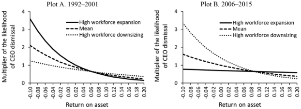

NOTE: figure/graphic rendered as an image from the PDF; its content is not machine-readable text. Caption (if any) follows as the next block.

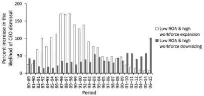

NOTE: figure/graphic rendered as an image from the PDF; its content is not machine-readable text. Caption (if any) follows as the next block.

the interaction estimates remain substantially unchanged in size and significance. The results of variance inflation factors (VIF) test show that multicollinearity problem is not severe in our regression models (mean VIF = 3.69 in Model 4; 3.82 in Model 8; 4.04 in Model 12). Taken together, the results show that, within an institutional context of shareholder primacy, the relationship between poor performance and CEO dismissal is weakened by high levels of downsizing and refocusing. They provide support for Hypothesis (H1a).

#### 4.1.1 | Changing role of downsizing and refocusing

Figure 2 depicts changes over time in the role of downsizing in CEO dismissal over a 10-year rolling window between 1980 and 2015. At each subperiod, the figure compares the effect of low ROA on the dismissal rate between the two groups of CEOs: high workforce expansion (open bar) and high workforce downsizing (filled bar). Notably, the group difference is negligible in the early subperiods. But it becomes pronounced especially for the subperiods of the late

FIGURE 1 Interaction effect of industry-adjusted return on asset (ROA) and workforce downsizing on chief executive officer (CEO) dismissal (based on Models 6 and 10 in Table 2). High workforce expansion (downsizing) = 1 SD above (below) the mean change in employees

FIGURE 2 Changing role of workforce downsizing in the relationship between poor firm performance and chief executive officer (CEO) dismissal, 1980–2015. Low return on asset (ROA) = 1 SD below the mean; high workforce expansion (downsizing) = 1 SD above (below) the mean change in employees

1248 SHIN ET AL.

Page 17

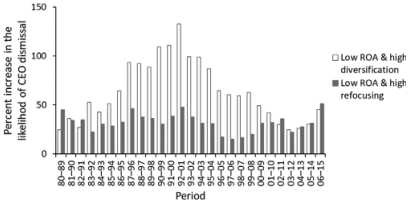

NOTE: figure/graphic rendered as an image from the PDF; its content is not machine-readable text. Caption (if any) follows as the next block.

#### 4.2 | CSR practices

Table 3 presents the models of CEO dismissal on ROA and its interaction with total CSR strengths for the two subperiods of 1992–2001 and 2006–2015 (Hypotheses (H2a) and (H2b)). At each subperiod, the first model is a baseline model including ROA, CSR strengths, CSR concerns, and controls; the others add one or both of the interaction terms for ROA with CSR strengths and ROA with CSR concerns. According to the results, the interaction estimate for ROA and CSR strengths is negative and significant for 1992–2001 (β = −2.65; p = .002); by contrast, it is positive and significant for 2006–2015 (β = 1.11; p = .005). This indicates substantial change in the role of CSR in CEO dismissal; while in the shareholder primacy era, the effect of

FIGURE 3 Changing role of business refocusing in the relationship between poor firm performance and chief executive officer (CEO) dismissal, 1980–2015. Low return on asset (ROA) = 1 SD below the mean; high diversification (refocusing) = 1 SD above (below) the mean change in diversification entropy

2The interaction effect of ROA and downsizing is negative and significant for all subperiods between 1984 and 2001 (p < .05). 3The interaction effect of ROA and refocusing is negative and significant for all subperiods between 1988 and 2006 (p < .05).

SHIN ET AL. 1249

Page 18

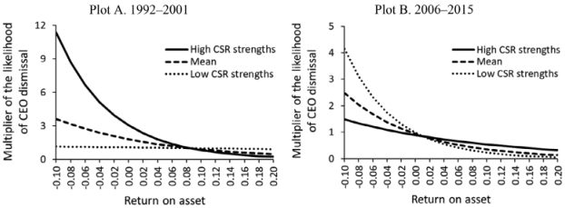

NOTE: figure/graphic rendered as an image from the PDF; its content is not machine-readable text. Caption (if any) follows as the next block.

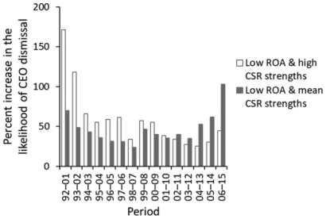

NOTE: figure/graphic rendered as an image from the PDF; its content is not machine-readable text. Caption (if any) follows as the next block.

poor performance on dismissal is strengthened by high CSR activity, that effect is weakened by the same activity in the post-Enron era. Meanwhile, the interaction estimate for ROA and CSR concerns is nonsignificant in both subperiods (Models 3 and 7). With both interaction terms added, the interaction estimate for ROA and CSR strengths remains unchanged (Models 4 and 8). Figure 4 illustrates the contrasting role of CSR strengths in dismissal between the two subperiods of 1992–2001 and 2006–2015. Each plot presents the effect of ROA on the dismissal rate at three levels of CSR strengths: high CSR strengths (1 SD above the mean), mean (the mean), and low CSR strengths (1 SD below the mean). Plot (a) shows that, when ROA declines, the dismissal rate increases most rapidly for high CSR strengths (bold line). In Plot (b), by contrast, the increase is most rapid for low CSR strengths (dotted line). Again, in both plots, the three lines are relatively flat at high levels of ROA. The results provide support for Hypotheses (H2a).

FIGURE 4 Interaction effect of industry-adjusted return on asset (ROA) and total corporate social responsibility (CSR) strengths on chief executive officer (CEO) dismissal (based on Models 2 and 6 in Table 3). High (low) CSR strengths = 1 SD above (below) the mean

FIGURE 5 Changing role of total corporate social responsibility (CSR) strengths in the relationship between poor firm performance and chief executive officer (CEO) dismissal, 1992–2015. Low return on asset (ROA) = 1 SD below the mean; high CSR strengths = 1 SD above the mean

1250 SHIN ET AL.

Page 19

#### 4.2.1 | Changing role of CSR

Figure 5 illustrates changes over time in the role of CSR strengths in dismissal between 1992 and 2015. At each subperiod, the figure compares the effect of low ROA on the dismissal rate between the two groups of CEOs: high CSR strengths (open bar) and mean CSR strengths (filled bar). It displays two striking trends. First, in the early subperiods between 1992 and 2006, the effect of low ROA on dismissal is significantly stronger for CEOs with higher CSR strengths. For instance, in 1992–2001, low ROA leads to increase in the dismissal rate by 171.5% for high CSR strengths, and 69.8% for mean CSR strengths. Second, in the recent subperiods between 2004 and 2015, the effect of low ROA on dismissal is weaker for CEOs with higher CSR strengths. For instance, in 2006–2015, low ROA leads to increase in the dismissal rate by 44.7% for high CSR strengths, and 103.0% for mean CSR strengths. The results indicate substantial changes in the board's reaction to CSR; while in the shareholder primacy era, the board reacts negatively to high CSR activity, it reacts positively toward the same activity in the post-Enron era. They provide support for Hypotheses (H2b).

#### 4.3 | Robustness checks

We conducted several sets of robustness checks that all confirm our findings, as summarized in Table 4. To begin with, we used alternative measures of refocusing. The first is the number of unrelated business divestitures. A business divestiture is defined as unrelated when the primary SIC code of the divested business unit is different from that of the divesting firm at the two-digit level. The second is the number of unrelated M&As. An M&A is defined as unrelated when the

TABLE 4 Summary of robustness checks

Variable Alternative measurement Data Finding

Engagement in

business refocusing

• Number of unrelated business Divestitures, t-2 to t-1

• SDC Platinum Consistent with findings from

the use of change in diversification entropy (Appendices 1–6) • Number of unrelated M&As, t-2 to t-1

• SDC Platinum

• Percent change in total assets, t-2 to t-1

• Compustat

Engagement in

stakeholder practices

• ESG score, t-1 • ASSET4 Consistent with findings from

the use of total CSR strengths (Appendices 7–10) • Net CSR score (total CSR strengths minus CSR concerns), t-1

• KLD

Firm financial

performance

• TSR • Compustat Consistent with findings from

the use of ROA (Appendices 11–13) • EPS • Compustat

• Tobin's Q • Compustat

Note: SDC Platinum is used to collect data on the divestitures and M&As that are announced and completed by the parent firms between January 1, 1980 and December 31, 2015. Appendices are available at https://www.timabansal.com. Abbreviations: CSR, corporate social responsibility; EPS, earnings per share; ROA, return on asset; TSR, total shareholder return.

SHIN ET AL. 1251

Page 20

two-digit SIC code of the acquiring firm's primary business does not match with that of the target firm. The third is percent change in total assets.

Moreover, we used alternative measures of CSR engagement. The first is the ASSET4 database, which contains times series data on ESG (Environmental, Social, and Governance) ratings from the year 2002. In the analysis, we used “ESG score” as a proxy for CSR practices and “ESG controversies score” as a proxy for CSiR practices. The second is an aggregate net KLD CSR score. It is noteworthy here that our findings are consistent with Hubbard, Christensen, and Graffin's (2017) research which analyzed the effect of net CSR score on the relationship between firm performance and CEO dismissal in 2003 to 2008. Specifically, we show that the effect of poor performance on dismissal becomes stronger for CEOs with higher net CSR score in the subperiods between 1992 and 2007. We extend their study by showing that such role of CSR is reversed for recent years, especially from 2010 onward.

Finally, we used alternative measures of performance, including total shareholder return (TSR), earnings per share (EPS), and Tobin's Q. TSR is equal to the change in year-end stock prices, plus annual dividends, divided by the prior year-end stock price. EPS is equal to net income divided by the number of outstanding shares for a given year. Tobin's Q is equal to the market value of total assets divided by the book value of total assets. These measures are calculated annually and are industry adjusted.

#### 5 | DISCUSSION AND CONCLUSION

The primary aim of this study was to weigh in on the debate as to whether or not the stakeholder perspective is growing in prominence over time. To do so, we examined the business practices that contributed to CEO dismissal under conditions of poor firm performance. Workforce downsizing and business refocusing signal an institutional context that supports shareholder primacy. CSR practices, on the other hand, signal an institutional context that supports a stakeholder orientation. We examined how shareholder- or stakeholder-oriented practices affect CEO dismissal and how such effects have changed over the last 35 years.

We found significant changes over time in the way boards of directors react to CEO practices that support shareholder primacy or stakeholder orientation. Specifically, before the 2000s, the effect of poor performance on CEO dismissal was weakened by high levels of downsizing and refocusing, but it was strengthened by high levels of CSR activity. This trend, however, reversed after the early 2000s. The findings suggest that, in the post-Enron era, the stakeholder perspective had become legitimated across the population of large U.S. firms, reflected by the penalties imposed on CEOs for their low commitment to social responsibility.

Our study provides evidence for an understanding of the cultural-normative processes associated with board perceptions and evaluations of CEOs during times of emergence of a stakeholder orientation. Specifically, we show that the growing prominence of a stakeholder orientation has led to changes in the way the board evaluates CEOs who are associated with shareholder- or stakeholder-oriented practices. Most strikingly, the board's reaction to CSR activity has substantially changed over time: while in the shareholder primacy era, boards react adversely to high CSR activity; in the post-Enron era, they react favorably toward the very same activity. We also show that, as the stakeholder perspective gains prominence, boards become increasingly adverse to the use of shareholder-oriented practices. Therefore, this article suggests that the characteristics of the prevailing institutional logics provide an important context when evaluating the quality of an organization's leaders.

1252 SHIN ET AL.

Page 21

Our findings reinforce the institutional argument that organizational goals, practices, and politics evolve in tandem with changes in higher-order institutional logics (Joseph et al., 2014; Ocasio & Kim, 1999; Thornton & Ocasio, 1999). This article shows that when an organization is using practices that embody the prevailing logic, managers are also held in greater esteem inside the organization. Specifically, within an institutional context with an agency logic, CEOs associated with the practices of downsizing and refocusing can gain internal support and avoid career penalty even during poor performance. By contrast, CEOs operating within a stakeholder logic can derive reputation from their commitment to taking social responsibility rather than shareholder primacy.

Consequently, this study suggests that the “rules of the game” for managers in large U.S. firms have changed over the past two decades, as the stakeholder perspective increasingly gained popularity as an alternative to shareholder primacy. Under the agency logic, the game was to increase the firm's market value. As such, managers were able to advance their careers by committing to practices that satisfied financial markets (Davis, 2009; Useem, 1996). Subsequently, as the movement toward a stakeholder orientation gained significant momentum, managers were expected to increase profits in a fashion to meet the expectations of a wide range of stakeholders. This study suggests that the changing rules of the game for CEO success are manifested in the way the board evaluates and treats CEOs with a stakeholder orientation.

This study offers a foundation for future research on the role of CSR in corporate governance. One feasible extension of this study would be to investigate the fate of agency logic in other countries. The Anglo-American model is purported to be introduced into many firms in Europe and Asia during the 1990s and 2000s (Ahmadjian & Robbins, 2005; Fiss & Zajac, 2004). Some commentators even argued for the diffusion of shareholder primacy as the world's standard (Hansmann & Kraakman, 2000). Meanwhile, there is evidence of the global CSR movement gaining significance over the past decades, and some countries, including the United Kingdom, Belgium, Canada, Denmark, and the Netherlands, instituted progressive policies toward CSR initiatives (Aguilera, Rupp, Williams, & Ganapathi, 2007). In this regard, Williams and Conley (2005, pp. 495–496) opined that “the historically unified Anglo-American front may be breaking down as a result of CSR advocates' actions and governments' and companies' reactions.” Therefore, there is a need for research on the institutional processes that affect the clash between shareholder- and stakeholder-based corporate governance systems.

Future research could also explore how the changing views and expectations of CSR have affected the way institutional investors react to a firm's high CSR activity. We know that the SRI movement has increasingly risen to prominence within the U.S. investor community (Marti & Gond, 2017; Revelli, 2017). It would be fruitful to examine whether institutional investors reward or punish firms for their high levels of CSR and how such rewards and penalties have changed over time. Given that institutional activism was a primary trigger for the rise of shareholder primacy, examining the changing relationship between CSR and institutional ownership can help improve our understanding of the changing corporate governance systems.

In recent years, there has been much talk of CSR, stakeholders, and sustainability, yet the corporate governance literature seems relatively steadfast in its assumption that corporate downsizing and refocusing are suitable responses to poor performance. Our research reveals that such actions are not objective, but interpretive and the appropriateness of such actions has changed over time. Both researchers and practicing managers would be served well by recognizing that the corporate governance practices associated with poor or good performance must be

SHIN ET AL. 1253

Page 22

interpreted within the prevailing institutional structures at the time, and much has changed in recent years.

ACKNOWLEDGEMENTS The authors are grateful to Ioannis Ioannou (the Editor), two anonymous reviewers, Heather Haveman, Neil Fligstein, Jiwook Jung, Roy Suddaby, Kyung-Pil Kim, and Maoliang Bu for their helpful comments and suggestions in previous drafts of this article. The paper has also benefited from comments from seminar participants at the Annual Meeting of the Academy of Management, the HBS Strategy Science Conference, the Sociology Department of Korea University, and Aalborg University Business School. This research has been supported by the Social Sciences and Humanities Research Council of Canada (Award Number: 435-2013-1409).

ORCID Shoonchul Shin https://orcid.org/0000-0003-4035-8851 Juyoung Lee https://orcid.org/0000-0001-6201-8722 Pratima (Tima) Bansal https://orcid.org/0000-0002-7899-9622

REFERENCES

Aguilera, R. V., Rupp, D. E., Williams, C. A., & Ganapathi, J. (2007). Putting the S back in corporate social

responsibility: A multilevel theory of social change in organizations. Academy of Management Review, 32(3), 836–863. Ahmadjian, C. L., & Robbins, G. E. (2005). A clash of capitalisms: Foreign shareholders and corporate restructur-

ing in 1990s Japan. American Sociological Review, 70(3), 451–471. Berrone, P., Cruz, C., Gomez-Mejia, L. R., & Larraza-Kintana, M. (2010). Socioemotional wealth and corporate

responses to institutional pressures: Do family-controlled firms pollute less? Administrative Science Quarterly, 55(1), 82–113. Bettinazzi, E. L., & Feldman, E. R. (2021). Stakeholder orientation and divestiture activity. Academy of Manage-

ment Journal., 64, 1078–1096. Bhagat, S., Shleifer, A., Vishny, R. W., Jarrel, G., & Summers, L. (1990). Hostile takeovers in the 1980s: The

return to corporate specialization. Brookings Papers on Economic Activity. Microeconomics, 1990, 1–84. Blossfeld, H., Golsch, K., & Rohwer, G. (2007). Event history analysis with Stata. Mahwah, NJ: Psychology Press. Box-Steffensmeier, J. M., & Stanfill, L. (2008). The cox proportional hazards model, diagnostics, and extensions.

In S. Menard (Ed.), Handbook of longitudinal research: Design, measurement, and analysis (pp. 405–419). Burlington, MA: Academic Press. Budros, A. (1997). The new capitalism and organizational rationality: The adoption of downsizing programs,

1979–1994. Social Forces, 76(1), 229–250. Business Roundtable. (1997). Statement on corporate governance. Washington, DC: Business Roundtable. Business Roundtable. (2019). Statement on the purpose of a corporation. Washington, DC: Business Roundtable. Cameron, K. S., Freeman, S. J., & Mishra, A. K. (1993). Downsizing and redesigning organizations. In G. P.

Huber & W. H. Glick (Eds.), Organizational change and redesign (pp. 19–63). New York, NY: Oxford University Press. Carroll, A. B. (1999). Corporate social responsibility: Evolution of a definitional construct. Business and Society,

38(3), 268–295. Datta, D. K., Guthrie, J. P., Basuil, D., & Pandey, A. (2010). Causes and effects of employee downsizing: A review

and synthesis. Journal of Management, 36(1), 281–348.

1254 SHIN ET AL.

Page 23

Davis, G. F. (2009). Managed by the markets: How finance re-shaped America. Oxford, England: Oxford University

Press. Davis, G. F., Diekmann, K. A., & Tinsley, C. H. (1994). The decline and fall of the conglomerate firm in the

1980s: The deinstitutionalization of an organizational form. American Sociological Review, 59(4), 547–570. Dial, J., & Murphy, K. J. (1995). Incentives, downsizing, and value creation at general dynamics. Journal of

Financial Economics, 37(3), 261–314. Dobbin, F., & Zorn, D. (2005). Corporate malfeasance and the myth of shareholder value. In D. E. Davis, Political

power and social theory (Vol. 17, pp. 179–198). Bingley: Emerald. Eccles, R. G., Ioannou, I., & Serafeim, G. (2014). The impact of corporate sustainability on organizational pro-

cesses and performance. Management Science, 60(11), 2835–2857. Fiss, P. C., & Zajac, E. J. (2004). The diffusion of ideas over contested terrain: The (non) adoption of a share-

holder value orientation among German firms. Administrative Science Quarterly, 49(4), 501–534. Flammer, C. (2013). Corporate social responsibility and shareholder reaction: The environmental awareness of

investors. Academy of Management Journal, 56(3), 758–781. Flammer, C. (2015). Does corporate social responsibility lead to superior financial performance? A regression dis-

continuity approach. Management Science, 61(11), 2549–2568. Flammer, C., & Ioannou, I. (2021). Strategic management during the financial crisis: How firms adjust their stra-

tegic investments in response to credit market disruptions. Strategic Management Journal, 42(7), 1275–1298. Fligstein, N. (1990). The transformation of corporate control. Cambridge, MA: Harvard University Press. Fligstein, N. (2001). The architecture of markets: An economic sociology of twenty-first-century capitalist societies.

Princeton, NJ: Princeton University Press. Fligstein, N., & Shin, T. (2007). Shareholder value and the transformation of the U.S. economy, 1984–2001. Socio-

logical Forum, 22(4), 399–424. Fombrun, C. J. (1996). Reputation: Realizing value from the corporate image. Boston, MA: Harvard Business

Review Press. Freeman, R. E. (1984). Strategic management: A stakeholder approach. Boston, MA: Pitman. Friedman, M. (1970). The social responsibility of business is to increase its profits. New York Times Magazine,

September 13, 32–33. Guerrera, F. (2009). Welch condemns share price focus. Financial Times. Haleblian, J., & Rajagopalan, N. (2006). A cognitive model of CEO dismissal: Understanding the influence of

board perceptions, attributions and efficacy beliefs. Journal of Management Studies, 43(5), 1009–1026. Hansmann, H., & Kraakman, R. (2000). The end of history for corporate law. Georgetown Law Journal, 89(2),

439–468. Harrison, J. S., Phillips, R. A., & Freeman, R. E. (2020). On the 2019 business Roundtable “statement on the pur-

pose of a corporation”. Journal of Management, 46(7), 1223–1237. Henderson, R. (2020). Reimagining capitalism in a world on fire. Public Affairs. New York, NY: Hachette Public

Affairs. Hong, H., & Kacperczyk, M. (2009). The price of sin: The effects of social norms on markets. Journal of Financial

Economics, 93(1), 15–36. Hoskisson, R. E., & Hitt, M. A. (1994). Downscoping: How to tame the diversified firm. New York, NY: Oxford

University Press. Hubbard, T. D., Christensen, D. M., & Graffin, S. D. (2017). Higher highs and lower lows: The role of corporate

social responsibility in CEO dismissal. Strategic Management Journal, 38(11), 2255–2265. Ioannou, I., & Serafeim, G. (2015). The impact of corporate social responsibility on investment recommenda-

tions: Analysts' perceptions and shifting institutional logics. Strategic Management Journal, 36(7), 1053– 1081. Jensen, M. C., & Meckling, W. H. (1976). Theory of the firm: Managerial behavior, agency costs and ownership

structure. Journal of Financial Economics, 3(4), 305–360. Jensen, M. C., & Zajac, E. J. (2004). Corporate elites and corporate strategy: How demographic preferences and

structural position shape the scope of the firm. Strategic Management Journal, 25(6), 507–524. Jones, T. M. (1995). Instrumental stakeholder theory: A synthesis of ethics and economics. Academy of Manage-

ment Review, 20(2), 404–437.

SHIN ET AL. 1255

Page 24

Joseph, J., Ocasio, W., & McDonnell, M.-H. (2014). The structural elaboration of board Independence: Executive

power, institutional logics, and the adoption of CEO-only board structures in U.S. corporate governance. Academy of Management Journal, 57(6), 1834–1858. Jung, J. (2015). Shareholder value and workforce downsizing, 1981–2006. Social Forces, 93(4), 1335–1368. Jung, J., & Shin, T. (2019). Learning not to diversify: The transformation of graduate business education and the

decline of diversifying acquisitions. Administrative Science Quarterly, 64(2), 337–369. Kennedy, M. T. (2008). Getting counted: Markets, media, and reality. American Sociological Review, 73(2),

270–295. Kiron, D., Kruschwitz, N., Haanaes, K., & von Streng Velken, I. (2012). Sustainability nears a tipping point. MIT

Sloan Management Review, 53(2), 69–74. Kramer, M. R., & Porter, M. (2011). Creating shared value. Harvard Business Review, 89(1/2), 62–77. Lubin, D. A., & Esty, D. C. (2010). The sustainability imperative. Harvard Business Review, 88(5), 42–50. Marti, E., & Gond, J.-P. (2017). When do theories become self-fulfilling? Exploring the boundary conditions of

performativity. Academy of Management Review, 43(3), 487–508. McKinley, W., Zhao, J., & Rust, K. G. (2000). A sociocognitive interpretation of organizational downsizing. Acad-

emy of Management Review, 25(1), 227–243. McWilliams, A., & Siegel, D. (2001). Corporate social responsibility: A theory of the firm perspective. The Acad-

emy of Management Review, 26(1), 117–127. Ocasio, W., & Kim, H. (1999). The circulation of corporate control: Selection of functional backgrounds of new

CEOs in large U.S. manufacturing firms, 1981–1992. Administrative Science Quarterly, 44(3), 532–562. Palepu, K. (1985). Diversification strategy, profit performance and the entropy measure. Strategic Management

Journal, 6(3), 239–255. Porter, M. E., & Kramer, M. R. (2002). The competitive advantage of corporate philanthropy. Harvard Business

Review, 80, 56–68. Reich, R. B. (2008). Supercapitalism: The transformation of business, democracy, and everyday life. New York, NY:

Vintage. Revelli, C. (2017). Socially responsible investing (SRI): From mainstream to margin? Research in International

Business and Finance, 39, 711–717. Semadeni, M., & Cannella, A. A., Jr. (2011). Examining the performance effects of post spin-off links to parent

firms: Should the apron strings be cut? Strategic Management Journal, 32(10), 1083–1098. Semadeni, M., Cannella, A. A., Jr., Fraser, D. R., & Lee, D. S. (2008). Fight or flight: Managing stigma in execu-

tive careers. Strategic Management Journal, 29(5), 557–567. Shen, W., & Cannella, A. A. (2002). Power dynamics within top management and their impacts on CEO dis-

missal followed by inside succession. Academy of Management Journal, 45(6), 1195–1206. Shin, S. (2019). The corporate restructuring imperative: Performance, strategy, and CEO dismissal in the share-

holder value era. Social Forces, 98(2), 794–818. Singer, J. D., & Willett, J. B. (2003). Applied longitudinal data analysis: Modeling change and event occurrence.

London: Oxford University Press. Sneirson, J. F. (2008). Green is good: Sustainability, profitability, and a new paradigm for corporate governance.

Iowa Law Review, 94(3), 987–1022. Staw, B. M., & Epstein, L. D. (2000). What bandwagons bring: Effects of popular management techniques on cor-

porate performance, reputation, and CEO pay. Administrative Science Quarterly, 45(3), 523–556. Stout, L. (2012). The shareholder value myth: How putting shareholders first harms investors, corporations, and the

public. San Francisco, CA: Berrett-Koehler Publishers. Strike, V. M., Gao, J., & Bansal, P. (2006). Being good while being bad: Social responsibility and the international

diversification of US firms. Journal of International Business Studies, 37(6), 850–862. Suchman, M. C. (1995). Managing legitimacy: Strategic and institutional approaches. Academy of Management

Review, 20(3), 571–610. Sundaram, A. K., & Inkpen, A. C. (2004). The corporate objective revisited. Organization Science, 15(3),

350–363. Thornton, P. H., & Ocasio, W. (1999). Institutional logics and the historical contingency of power in organiza-

tions: Executive succession in the higher education publishing industry, 1958–1990. American Journal of Sociology, 105(3), 801–843.

1256 SHIN ET AL.

Page 25

Useem, M. (1996). Investor capitalism: How money managers are changing the face of corporate America. New

York, NY: Basic Books. Vogel, D. J. (2005). Is there a market for virtue?: The business case for corporate social responsibility. California

Management Review, 47(4), 19–45. Waddock, S. (2008). Building a new institutional infrastructure for corporate responsibility. Academy of Manage-

ment Perspectives, 22(3), 87–108. Williams, C. A., & Conley, J. M. (2005). An Emerging Third Way - The Erosion of the Anglo-American Share-

holder Value Construct. Cornell International Law Journal, 38(2), 493–552. Wowak, A. J., Hambrick, D. C., & Henderson, A. D. (2011). Do CEOs encounter within-tenure settling up? A

multiperiod perspective on executive pay and dismissal. Academy of Management Journal, 54(4), 719–739. Zuckerman, E. W. (1999). The categorical imperative: Securities analysts and the illegitimacy discount. American

Journal of Sociology, 104(5), 1398–1438.

How to cite this article: Shin, S., Lee, J., & Bansal, P. (T.) (2022). From a shareholder to stakeholder orientation: Evidence from the analyses of CEO dismissal in large U.S. firms. Strategic Management Journal, 43(7), 1233–1257. https://doi.org/10.1002/smj.3369

SHIN ET AL. 1257